# Risk Factor Analysis

## Outcome Variable

**Outcome Variable:** haz

## Predictor Variables

**Intervention Variable:** single

**Adjustment Set:**

unadjusted

## Stratifying Variables

The analysis was stratified on these variable(s):

- agecat
- studyid
- country

## Data Summary

| agecat | studyid | country | single | n_cell | n |
| --- | --- | --- | --- | --- | --- |
| Birth | ki0047075b-MAL-ED | BANGLADESH | 0 | 257 | 257 |
| Birth | ki0047075b-MAL-ED | BANGLADESH | 1 | 0 | 257 |
| Birth | ki0047075b-MAL-ED | BRAZIL | 0 | 166 | 191 |
| Birth | ki0047075b-MAL-ED | BRAZIL | 1 | 25 | 191 |
| Birth | ki0047075b-MAL-ED | INDIA | 0 | 205 | 205 |
| Birth | ki0047075b-MAL-ED | INDIA | 1 | 0 | 205 |
| Birth | ki0047075b-MAL-ED | NEPAL | 0 | 173 | 173 |
| Birth | ki0047075b-MAL-ED | NEPAL | 1 | 0 | 173 |
| Birth | ki0047075b-MAL-ED | PERU | 0 | 253 | 287 |
| Birth | ki0047075b-MAL-ED | PERU | 1 | 34 | 287 |
| Birth | ki0047075b-MAL-ED | SOUTH AFRICA | 0 | 146 | 262 |
| Birth | ki0047075b-MAL-ED | SOUTH AFRICA | 1 | 116 | 262 |
| Birth | ki0047075b-MAL-ED | TANZANIA, UNITED REPUBLIC OF | 0 | 117 | 123 |
| Birth | ki0047075b-MAL-ED | TANZANIA, UNITED REPUBLIC OF | 1 | 6 | 123 |
| Birth | ki1119695-PROBIT | BELARUS | 0 | 13343 | 13884 |
| Birth | ki1119695-PROBIT | BELARUS | 1 | 541 | 13884 |
| Birth | ki1126311-ZVITAMBO | ZIMBABWE | 0 | 12902 | 13772 |
| Birth | ki1126311-ZVITAMBO | ZIMBABWE | 1 | 870 | 13772 |
| Birth | ki1135781-COHORTS | GUATEMALA | 0 | 719 | 767 |
| Birth | ki1135781-COHORTS | GUATEMALA | 1 | 48 | 767 |
| Birth | ki1135781-COHORTS | INDIA | 0 | 4771 | 4778 |
| Birth | ki1135781-COHORTS | INDIA | 1 | 7 | 4778 |
| Birth | ki1135781-COHORTS | PHILIPPINES | 0 | 2936 | 3010 |
| Birth | ki1135781-COHORTS | PHILIPPINES | 1 | 74 | 3010 |
| 6 months | ki0047075b-MAL-ED | BANGLADESH | 0 | 241 | 241 |
| 6 months | ki0047075b-MAL-ED | BANGLADESH | 1 | 0 | 241 |
| 6 months | ki0047075b-MAL-ED | BRAZIL | 0 | 179 | 209 |
| 6 months | ki0047075b-MAL-ED | BRAZIL | 1 | 30 | 209 |
| 6 months | ki0047075b-MAL-ED | INDIA | 0 | 234 | 234 |
| 6 months | ki0047075b-MAL-ED | INDIA | 1 | 0 | 234 |
| 6 months | ki0047075b-MAL-ED | NEPAL | 0 | 236 | 236 |
| 6 months | ki0047075b-MAL-ED | NEPAL | 1 | 0 | 236 |
| 6 months | ki0047075b-MAL-ED | PERU | 0 | 240 | 273 |
| 6 months | ki0047075b-MAL-ED | PERU | 1 | 33 | 273 |
| 6 months | ki0047075b-MAL-ED | SOUTH AFRICA | 0 | 140 | 254 |
| 6 months | ki0047075b-MAL-ED | SOUTH AFRICA | 1 | 114 | 254 |
| 6 months | ki0047075b-MAL-ED | TANZANIA, UNITED REPUBLIC OF | 0 | 239 | 247 |
| 6 months | ki0047075b-MAL-ED | TANZANIA, UNITED REPUBLIC OF | 1 | 8 | 247 |
| 6 months | ki1066203-TanzaniaChild2 | TANZANIA, UNITED REPUBLIC OF | 0 | 1835 | 2013 |
| 6 months | ki1066203-TanzaniaChild2 | TANZANIA, UNITED REPUBLIC OF | 1 | 178 | 2013 |
| 6 months | ki1112895-Guatemala BSC | GUATEMALA | 0 | 248 | 277 |
| 6 months | ki1112895-Guatemala BSC | GUATEMALA | 1 | 29 | 277 |
| 6 months | ki1119695-PROBIT | BELARUS | 0 | 15118 | 15761 |
| 6 months | ki1119695-PROBIT | BELARUS | 1 | 643 | 15761 |
| 6 months | ki1126311-ZVITAMBO | ZIMBABWE | 0 | 7775 | 8265 |
| 6 months | ki1126311-ZVITAMBO | ZIMBABWE | 1 | 490 | 8265 |
| 6 months | ki1135781-COHORTS | GUATEMALA | 0 | 826 | 893 |
| 6 months | ki1135781-COHORTS | GUATEMALA | 1 | 67 | 893 |
| 6 months | ki1135781-COHORTS | INDIA | 0 | 4962 | 4971 |
| 6 months | ki1135781-COHORTS | INDIA | 1 | 9 | 4971 |
| 6 months | ki1135781-COHORTS | PHILIPPINES | 0 | 2608 | 2676 |
| 6 months | ki1135781-COHORTS | PHILIPPINES | 1 | 68 | 2676 |
| 24 months | ki0047075b-MAL-ED | BANGLADESH | 0 | 212 | 212 |
| 24 months | ki0047075b-MAL-ED | BANGLADESH | 1 | 0 | 212 |
| 24 months | ki0047075b-MAL-ED | BRAZIL | 0 | 148 | 169 |
| 24 months | ki0047075b-MAL-ED | BRAZIL | 1 | 21 | 169 |
| 24 months | ki0047075b-MAL-ED | INDIA | 0 | 225 | 225 |
| 24 months | ki0047075b-MAL-ED | INDIA | 1 | 0 | 225 |
| 24 months | ki0047075b-MAL-ED | NEPAL | 0 | 228 | 228 |
| 24 months | ki0047075b-MAL-ED | NEPAL | 1 | 0 | 228 |
| 24 months | ki0047075b-MAL-ED | PERU | 0 | 176 | 201 |
| 24 months | ki0047075b-MAL-ED | PERU | 1 | 25 | 201 |
| 24 months | ki0047075b-MAL-ED | SOUTH AFRICA | 0 | 131 | 238 |
| 24 months | ki0047075b-MAL-ED | SOUTH AFRICA | 1 | 107 | 238 |
| 24 months | ki0047075b-MAL-ED | TANZANIA, UNITED REPUBLIC OF | 0 | 208 | 214 |
| 24 months | ki0047075b-MAL-ED | TANZANIA, UNITED REPUBLIC OF | 1 | 6 | 214 |
| 24 months | ki1066203-TanzaniaChild2 | TANZANIA, UNITED REPUBLIC OF | 0 | 6 | 6 |
| 24 months | ki1066203-TanzaniaChild2 | TANZANIA, UNITED REPUBLIC OF | 1 | 0 | 6 |
| 24 months | ki1119695-PROBIT | BELARUS | 0 | 3890 | 4035 |
| 24 months | ki1119695-PROBIT | BELARUS | 1 | 145 | 4035 |
| 24 months | ki1126311-ZVITAMBO | ZIMBABWE | 0 | 413 | 456 |
| 24 months | ki1126311-ZVITAMBO | ZIMBABWE | 1 | 43 | 456 |
| 24 months | ki1135781-COHORTS | GUATEMALA | 0 | 926 | 1013 |
| 24 months | ki1135781-COHORTS | GUATEMALA | 1 | 87 | 1013 |
| 24 months | ki1135781-COHORTS | INDIA | 0 | 3747 | 3756 |
| 24 months | ki1135781-COHORTS | INDIA | 1 | 9 | 3756 |
| 24 months | ki1135781-COHORTS | PHILIPPINES | 0 | 2357 | 2416 |
| 24 months | ki1135781-COHORTS | PHILIPPINES | 1 | 59 | 2416 |

The following strata were considered:

- agecat: 24 months, studyid: ki0047075b-MAL-ED, country: BANGLADESH
- agecat: 24 months, studyid: ki0047075b-MAL-ED, country: BRAZIL
- agecat: 24 months, studyid: ki0047075b-MAL-ED, country: INDIA
- agecat: 24 months, studyid: ki0047075b-MAL-ED, country: NEPAL
- agecat: 24 months, studyid: ki0047075b-MAL-ED, country: PERU
- agecat: 24 months, studyid: ki0047075b-MAL-ED, country: SOUTH AFRICA
- agecat: 24 months, studyid: ki0047075b-MAL-ED, country: TANZANIA, UNITED REPUBLIC OF
- agecat: 24 months, studyid: ki1066203-TanzaniaChild2, country: TANZANIA, UNITED REPUBLIC OF
- agecat: 24 months, studyid: ki1119695-PROBIT, country: BELARUS
- agecat: 24 months, studyid: ki1126311-ZVITAMBO, country: ZIMBABWE
- agecat: 24 months, studyid: ki1135781-COHORTS, country: GUATEMALA
- agecat: 24 months, studyid: ki1135781-COHORTS, country: INDIA
- agecat: 24 months, studyid: ki1135781-COHORTS, country: PHILIPPINES
- agecat: 6 months, studyid: ki0047075b-MAL-ED, country: BANGLADESH
- agecat: 6 months, studyid: ki0047075b-MAL-ED, country: BRAZIL
- agecat: 6 months, studyid: ki0047075b-MAL-ED, country: INDIA
- agecat: 6 months, studyid: ki0047075b-MAL-ED, country: NEPAL
- agecat: 6 months, studyid: ki0047075b-MAL-ED, country: PERU
- agecat: 6 months, studyid: ki0047075b-MAL-ED, country: SOUTH AFRICA
- agecat: 6 months, studyid: ki0047075b-MAL-ED, country: TANZANIA, UNITED REPUBLIC OF
- agecat: 6 months, studyid: ki1066203-TanzaniaChild2, country: TANZANIA, UNITED REPUBLIC OF
- agecat: 6 months, studyid: ki1112895-Guatemala BSC, country: GUATEMALA
- agecat: 6 months, studyid: ki1119695-PROBIT, country: BELARUS
- agecat: 6 months, studyid: ki1126311-ZVITAMBO, country: ZIMBABWE
- agecat: 6 months, studyid: ki1135781-COHORTS, country: GUATEMALA
- agecat: 6 months, studyid: ki1135781-COHORTS, country: INDIA
- agecat: 6 months, studyid: ki1135781-COHORTS, country: PHILIPPINES
- agecat: Birth, studyid: ki0047075b-MAL-ED, country: BANGLADESH
- agecat: Birth, studyid: ki0047075b-MAL-ED, country: BRAZIL
- agecat: Birth, studyid: ki0047075b-MAL-ED, country: INDIA
- agecat: Birth, studyid: ki0047075b-MAL-ED, country: NEPAL
- agecat: Birth, studyid: ki0047075b-MAL-ED, country: PERU
- agecat: Birth, studyid: ki0047075b-MAL-ED, country: SOUTH AFRICA
- agecat: Birth, studyid: ki0047075b-MAL-ED, country: TANZANIA, UNITED REPUBLIC OF
- agecat: Birth, studyid: ki1119695-PROBIT, country: BELARUS
- agecat: Birth, studyid: ki1126311-ZVITAMBO, country: ZIMBABWE
- agecat: Birth, studyid: ki1135781-COHORTS, country: GUATEMALA
- agecat: Birth, studyid: ki1135781-COHORTS, country: INDIA
- agecat: Birth, studyid: ki1135781-COHORTS, country: PHILIPPINES

### Dropped Strata

- agecat: Birth, studyid: ki0047075b-MAL-ED, country: BANGLADESH
- agecat: Birth, studyid: ki0047075b-MAL-ED, country: INDIA
- agecat: Birth, studyid: ki0047075b-MAL-ED, country: NEPAL
- agecat: 6 months, studyid: ki0047075b-MAL-ED, country: BANGLADESH
- agecat: 6 months, studyid: ki0047075b-MAL-ED, country: INDIA
- agecat: 6 months, studyid: ki0047075b-MAL-ED, country: NEPAL
- agecat: 24 months, studyid: ki0047075b-MAL-ED, country: BANGLADESH
- agecat: 24 months, studyid: ki0047075b-MAL-ED, country: INDIA
- agecat: 24 months, studyid: ki0047075b-MAL-ED, country: NEPAL
- agecat: 24 months, studyid: ki1066203-TanzaniaChild2, country: TANZANIA, UNITED REPUBLIC OF

## Methods Detail

We’re interested in the causal parameters $E[Y_a]$ for all values of $a \in \mathcal{A}$. These parameters represent the mean outcome if, possibly contrary to fact, we intervened to set all units to have $A=a$. Under the randomization and positivity assumptions, these are identified by the statistical parameters $\psi_a=E_W[E_{Y|A,W}(Y|A=a,W)]$. In addition, we’re interested in the mean of $Y$, $E[Y]$ under no intervention (the observed mean). We will estimate these parameters by using SuperLearner to fit the relevant likelihood factors – $E_{Y|A,W}(Y|A=a,W)$ and $p(A=a|W)$, and then updating our likelihood fit using a joint TMLE.

For unadjusted analyses ($W=\{\}$), initial likelihoods were estimated using Lrnr_glm to estimate the simple $E(Y|A)$ and Lrnr_mean to estimate $p(A)$. For adjusted analyses, a small library containing Lrnr_glmnet, Lrnr_xgboost, and Lrnr_mean was used.

Having estimated these parameters, we will then use the delta method to estimate relative risks and attributable risks relative to a prespecified baseline level of $A$.

# Results Detail

## Results Plots

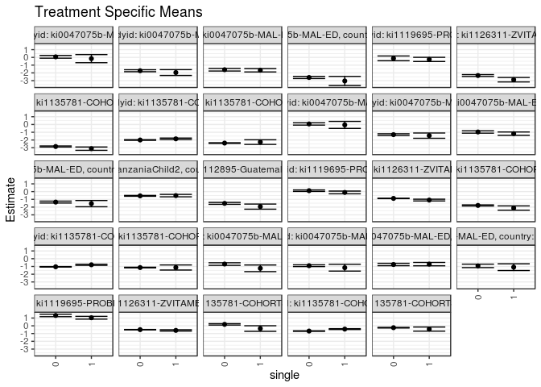

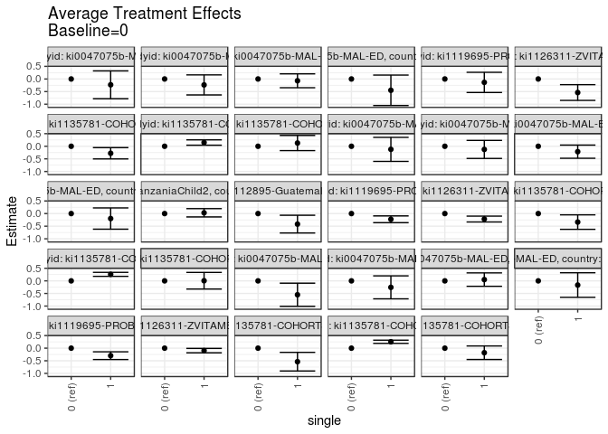

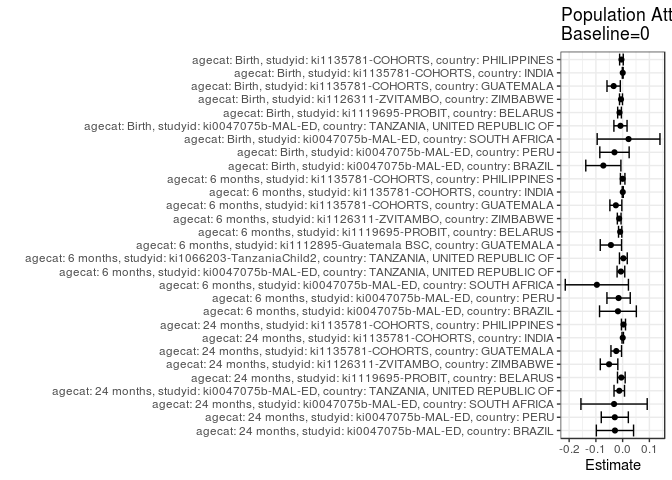

## Results Table

### Parameter: TSM

| agecat | studyid | country | intervention_level | baseline_level | estimate | ci_lower | ci_upper |
| --- | --- | --- | --- | --- | --- | --- | --- |
| Birth | ki0047075b-MAL-ED | BRAZIL | 0 | NA | -0.6887952 | -0.8546439 | -0.5229465 |
| Birth | ki0047075b-MAL-ED | BRAZIL | 1 | NA | -1.2400000 | -1.6680235 | -0.8119765 |
| Birth | ki0047075b-MAL-ED | PERU | 0 | NA | -0.9017391 | -1.0160300 | -0.7874483 |
| Birth | ki0047075b-MAL-ED | PERU | 1 | NA | -1.1591176 | -1.6000539 | -0.7181814 |
| Birth | ki0047075b-MAL-ED | SOUTH AFRICA | 0 | NA | -0.7487671 | -0.9022846 | -0.5952497 |
| Birth | ki0047075b-MAL-ED | SOUTH AFRICA | 1 | NA | -0.6987069 | -0.9147687 | -0.4826451 |
| Birth | ki0047075b-MAL-ED | TANZANIA, UNITED REPUBLIC OF | 0 | NA | -0.9257265 | -1.1481121 | -0.7033409 |
| Birth | ki0047075b-MAL-ED | TANZANIA, UNITED REPUBLIC OF | 1 | NA | -1.0916667 | -1.5252286 | -0.6581047 |
| Birth | ki1119695-PROBIT | BELARUS | 0 | NA | 1.3370839 | 1.1767204 | 1.4974473 |
| Birth | ki1119695-PROBIT | BELARUS | 1 | NA | 1.0392237 | 0.8588981 | 1.2195492 |
| Birth | ki1126311-ZVITAMBO | ZIMBABWE | 0 | NA | -0.4953806 | -0.5166019 | -0.4741592 |
| Birth | ki1126311-ZVITAMBO | ZIMBABWE | 1 | NA | -0.5919655 | -0.6767493 | -0.5071817 |
| Birth | ki1135781-COHORTS | GUATEMALA | 0 | NA | 0.1846871 | 0.0945983 | 0.2747758 |
| Birth | ki1135781-COHORTS | GUATEMALA | 1 | NA | -0.3516667 | -0.7107876 | 0.0074543 |
| Birth | ki1135781-COHORTS | INDIA | 0 | NA | -0.6778139 | -0.7115208 | -0.6441070 |
| Birth | ki1135781-COHORTS | INDIA | 1 | NA | -0.4242857 | -0.4784569 | -0.3701145 |
| Birth | ki1135781-COHORTS | PHILIPPINES | 0 | NA | -0.2421117 | -0.2816143 | -0.2026092 |
| Birth | ki1135781-COHORTS | PHILIPPINES | 1 | NA | -0.4228378 | -0.6883020 | -0.1573737 |
| 6 months | ki0047075b-MAL-ED | BRAZIL | 0 | NA | 0.0685754 | -0.0813155 | 0.2184663 |
| 6 months | ki0047075b-MAL-ED | BRAZIL | 1 | NA | -0.0537222 | -0.5070021 | 0.3995576 |
| 6 months | ki0047075b-MAL-ED | PERU | 0 | NA | -1.3116736 | -1.4255602 | -1.1977871 |
| 6 months | ki0047075b-MAL-ED | PERU | 1 | NA | -1.4368182 | -1.7764892 | -1.0971472 |
| 6 months | ki0047075b-MAL-ED | SOUTH AFRICA | 0 | NA | -0.9669881 | -1.1191736 | -0.8148026 |
| 6 months | ki0047075b-MAL-ED | SOUTH AFRICA | 1 | NA | -1.1817471 | -1.3943646 | -0.9691295 |
| 6 months | ki0047075b-MAL-ED | TANZANIA, UNITED REPUBLIC OF | 0 | NA | -1.3537169 | -1.4790610 | -1.2283727 |
| 6 months | ki0047075b-MAL-ED | TANZANIA, UNITED REPUBLIC OF | 1 | NA | -1.5514583 | -1.9539746 | -1.1489420 |
| 6 months | ki1066203-TanzaniaChild2 | TANZANIA, UNITED REPUBLIC OF | 0 | NA | -0.5484818 | -0.6001349 | -0.4968287 |
| 6 months | ki1066203-TanzaniaChild2 | TANZANIA, UNITED REPUBLIC OF | 1 | NA | -0.5178371 | -0.6741242 | -0.3615500 |
| 6 months | ki1112895-Guatemala BSC | GUATEMALA | 0 | NA | -1.5186358 | -1.6410623 | -1.3962092 |
| 6 months | ki1112895-Guatemala BSC | GUATEMALA | 1 | NA | -1.9370115 | -2.2670985 | -1.6069245 |
| 6 months | ki1119695-PROBIT | BELARUS | 0 | NA | 0.1162436 | 0.0221189 | 0.2103682 |
| 6 months | ki1119695-PROBIT | BELARUS | 1 | NA | -0.1103655 | -0.2862279 | 0.0654969 |
| 6 months | ki1126311-ZVITAMBO | ZIMBABWE | 0 | NA | -0.8777627 | -0.9044710 | -0.8510544 |
| 6 months | ki1126311-ZVITAMBO | ZIMBABWE | 1 | NA | -1.0946531 | -1.2072136 | -0.9820925 |
| 6 months | ki1135781-COHORTS | GUATEMALA | 0 | NA | -1.7836199 | -1.8568602 | -1.7103795 |
| 6 months | ki1135781-COHORTS | GUATEMALA | 1 | NA | -2.1211940 | -2.3989115 | -1.8434765 |
| 6 months | ki1135781-COHORTS | INDIA | 0 | NA | -1.0423478 | -1.0757913 | -1.0089044 |
| 6 months | ki1135781-COHORTS | INDIA | 1 | NA | -0.7833333 | -0.8545896 | -0.7120771 |
| 6 months | ki1135781-COHORTS | PHILIPPINES | 0 | NA | -1.1415798 | -1.1840577 | -1.0991018 |
| 6 months | ki1135781-COHORTS | PHILIPPINES | 1 | NA | -1.1361765 | -1.4629462 | -0.8094067 |
| 24 months | ki0047075b-MAL-ED | BRAZIL | 0 | NA | 0.0705743 | -0.1048187 | 0.2459674 |
| 24 months | ki0047075b-MAL-ED | BRAZIL | 1 | NA | -0.1607143 | -0.6844974 | 0.3630689 |
| 24 months | ki0047075b-MAL-ED | PERU | 0 | NA | -1.7208239 | -1.8469307 | -1.5947170 |
| 24 months | ki0047075b-MAL-ED | PERU | 1 | NA | -1.9562000 | -2.3332075 | -1.5791925 |
| 24 months | ki0047075b-MAL-ED | SOUTH AFRICA | 0 | NA | -1.5908015 | -1.7618770 | -1.4197261 |
| 24 months | ki0047075b-MAL-ED | SOUTH AFRICA | 1 | NA | -1.6620561 | -1.8778703 | -1.4462418 |
| 24 months | ki0047075b-MAL-ED | TANZANIA, UNITED REPUBLIC OF | 0 | NA | -2.5933173 | -2.7301853 | -2.4564493 |
| 24 months | ki0047075b-MAL-ED | TANZANIA, UNITED REPUBLIC OF | 1 | NA | -3.0416667 | -3.6297264 | -2.4536070 |
| 24 months | ki1119695-PROBIT | BELARUS | 0 | NA | -0.1265420 | -0.4337272 | 0.1806432 |
| 24 months | ki1119695-PROBIT | BELARUS | 1 | NA | -0.2618621 | -0.5309526 | 0.0072285 |
| 24 months | ki1126311-ZVITAMBO | ZIMBABWE | 0 | NA | -2.3417676 | -2.4634879 | -2.2200472 |
| 24 months | ki1126311-ZVITAMBO | ZIMBABWE | 1 | NA | -2.8797674 | -3.1669987 | -2.5925362 |
| 24 months | ki1135781-COHORTS | GUATEMALA | 0 | NA | -2.8405616 | -2.9101119 | -2.7710113 |
| 24 months | ki1135781-COHORTS | GUATEMALA | 1 | NA | -3.1181609 | -3.3311015 | -2.9052204 |
| 24 months | ki1135781-COHORTS | INDIA | 0 | NA | -2.0012143 | -2.0414003 | -1.9610283 |
| 24 months | ki1135781-COHORTS | INDIA | 1 | NA | -1.8522222 | -1.9508516 | -1.7535928 |
| 24 months | ki1135781-COHORTS | PHILIPPINES | 0 | NA | -2.3993636 | -2.4449931 | -2.3537341 |
| 24 months | ki1135781-COHORTS | PHILIPPINES | 1 | NA | -2.2706780 | -2.5680152 | -1.9733408 |

### Parameter: E(Y)

| agecat | studyid | country | intervention_level | baseline_level | estimate | ci_lower | ci_upper |
| --- | --- | --- | --- | --- | --- | --- | --- |
| Birth | ki0047075b-MAL-ED | BRAZIL | NA | NA | -0.7609424 | -0.9178311 | -0.6040538 |
| Birth | ki0047075b-MAL-ED | PERU | NA | NA | -0.9322300 | -1.0461262 | -0.8183337 |
| Birth | ki0047075b-MAL-ED | SOUTH AFRICA | NA | NA | -0.7266031 | -0.8549719 | -0.5982342 |
| Birth | ki0047075b-MAL-ED | TANZANIA, UNITED REPUBLIC OF | NA | NA | -0.9338211 | -1.1465079 | -0.7211344 |
| Birth | ki1119695-PROBIT | BELARUS | NA | NA | 1.3254775 | 1.1669293 | 1.4840258 |
| Birth | ki1126311-ZVITAMBO | ZIMBABWE | NA | NA | -0.5014820 | -0.5220753 | -0.4808887 |
| Birth | ki1135781-COHORTS | GUATEMALA | NA | NA | 0.1511213 | 0.0632481 | 0.2389944 |
| Birth | ki1135781-COHORTS | INDIA | NA | NA | -0.6774424 | -0.7103357 | -0.6445492 |
| Birth | ki1135781-COHORTS | PHILIPPINES | NA | NA | -0.2465548 | -0.2856502 | -0.2074594 |
| 6 months | ki0047075b-MAL-ED | BRAZIL | NA | NA | 0.0510207 | -0.0930194 | 0.1950608 |
| 6 months | ki0047075b-MAL-ED | PERU | NA | NA | -1.3268010 | -1.4351217 | -1.2184802 |
| 6 months | ki0047075b-MAL-ED | SOUTH AFRICA | NA | NA | -1.0633760 | -1.1911088 | -0.9356432 |
| 6 months | ki0047075b-MAL-ED | TANZANIA, UNITED REPUBLIC OF | NA | NA | -1.3601215 | -1.4821830 | -1.2380600 |
| 6 months | ki1066203-TanzaniaChild2 | TANZANIA, UNITED REPUBLIC OF | NA | NA | -0.5457721 | -0.5948454 | -0.4966988 |
| 6 months | ki1112895-Guatemala BSC | GUATEMALA | NA | NA | -1.5624368 | -1.6783540 | -1.4465196 |
| 6 months | ki1119695-PROBIT | BELARUS | NA | NA | 0.1069986 | 0.0122286 | 0.2017686 |
| 6 months | ki1126311-ZVITAMBO | ZIMBABWE | NA | NA | -0.8906213 | -0.9166407 | -0.8646018 |
| 6 months | ki1135781-COHORTS | GUATEMALA | NA | NA | -1.8089474 | -1.8800645 | -1.7378303 |
| 6 months | ki1135781-COHORTS | INDIA | NA | NA | -1.0418789 | -1.0745363 | -1.0092215 |
| 6 months | ki1135781-COHORTS | PHILIPPINES | NA | NA | -1.1414425 | -1.1836656 | -1.0992193 |
| 24 months | ki0047075b-MAL-ED | BRAZIL | NA | NA | 0.0418343 | -0.1253834 | 0.2090521 |
| 24 months | ki0047075b-MAL-ED | PERU | NA | NA | -1.7500995 | -1.8705474 | -1.6296516 |
| 24 months | ki0047075b-MAL-ED | SOUTH AFRICA | NA | NA | -1.6228361 | -1.7581177 | -1.4875546 |
| 24 months | ki0047075b-MAL-ED | TANZANIA, UNITED REPUBLIC OF | NA | NA | -2.6058879 | -2.7403043 | -2.4714714 |
| 24 months | ki1119695-PROBIT | BELARUS | NA | NA | -0.1314048 | -0.4282725 | 0.1654630 |
| 24 months | ki1126311-ZVITAMBO | ZIMBABWE | NA | NA | -2.3925000 | -2.5069364 | -2.2780636 |
| 24 months | ki1135781-COHORTS | GUATEMALA | NA | NA | -2.8644028 | -2.9307312 | -2.7980743 |
| 24 months | ki1135781-COHORTS | INDIA | NA | NA | -2.0008573 | -2.0401168 | -1.9615978 |
| 24 months | ki1135781-COHORTS | PHILIPPINES | NA | NA | -2.3962210 | -2.4413335 | -2.3511085 |

### Parameter: ATE

| agecat | studyid | country | intervention_level | baseline_level | estimate | ci_lower | ci_upper |
| --- | --- | --- | --- | --- | --- | --- | --- |
| Birth | ki0047075b-MAL-ED | BRAZIL | 0 | 0 | 0.0000000 | 0.0000000 | 0.0000000 |
| Birth | ki0047075b-MAL-ED | BRAZIL | 1 | 0 | -0.5512048 | -1.0102363 | -0.0921733 |
| Birth | ki0047075b-MAL-ED | PERU | 0 | 0 | 0.0000000 | 0.0000000 | 0.0000000 |
| Birth | ki0047075b-MAL-ED | PERU | 1 | 0 | -0.2573785 | -0.7128861 | 0.1981291 |
| Birth | ki0047075b-MAL-ED | SOUTH AFRICA | 0 | 0 | 0.0000000 | 0.0000000 | 0.0000000 |
| Birth | ki0047075b-MAL-ED | SOUTH AFRICA | 1 | 0 | 0.0500602 | -0.2149875 | 0.3151080 |
| Birth | ki0047075b-MAL-ED | TANZANIA, UNITED REPUBLIC OF | 0 | 0 | 0.0000000 | 0.0000000 | 0.0000000 |
| Birth | ki0047075b-MAL-ED | TANZANIA, UNITED REPUBLIC OF | 1 | 0 | -0.1659402 | -0.6532094 | 0.3213291 |
| Birth | ki1119695-PROBIT | BELARUS | 0 | 0 | 0.0000000 | 0.0000000 | 0.0000000 |
| Birth | ki1119695-PROBIT | BELARUS | 1 | 0 | -0.2978602 | -0.4513877 | -0.1443327 |
| Birth | ki1126311-ZVITAMBO | ZIMBABWE | 0 | 0 | 0.0000000 | 0.0000000 | 0.0000000 |
| Birth | ki1126311-ZVITAMBO | ZIMBABWE | 1 | 0 | -0.0965850 | -0.1839843 | -0.0091856 |
| Birth | ki1135781-COHORTS | GUATEMALA | 0 | 0 | 0.0000000 | 0.0000000 | 0.0000000 |
| Birth | ki1135781-COHORTS | GUATEMALA | 1 | 0 | -0.5363537 | -0.9066021 | -0.1661054 |
| Birth | ki1135781-COHORTS | INDIA | 0 | 0 | 0.0000000 | 0.0000000 | 0.0000000 |
| Birth | ki1135781-COHORTS | INDIA | 1 | 0 | 0.2535282 | 0.1897264 | 0.3173300 |
| Birth | ki1135781-COHORTS | PHILIPPINES | 0 | 0 | 0.0000000 | 0.0000000 | 0.0000000 |
| Birth | ki1135781-COHORTS | PHILIPPINES | 1 | 0 | -0.1807261 | -0.4491133 | 0.0876611 |
| 6 months | ki0047075b-MAL-ED | BRAZIL | 0 | 0 | 0.0000000 | 0.0000000 | 0.0000000 |
| 6 months | ki0047075b-MAL-ED | BRAZIL | 1 | 0 | -0.1222976 | -0.5997177 | 0.3551224 |
| 6 months | ki0047075b-MAL-ED | PERU | 0 | 0 | 0.0000000 | 0.0000000 | 0.0000000 |
| 6 months | ki0047075b-MAL-ED | PERU | 1 | 0 | -0.1251446 | -0.4833994 | 0.2331103 |
| 6 months | ki0047075b-MAL-ED | SOUTH AFRICA | 0 | 0 | 0.0000000 | 0.0000000 | 0.0000000 |
| 6 months | ki0047075b-MAL-ED | SOUTH AFRICA | 1 | 0 | -0.2147590 | -0.4762292 | 0.0467112 |
| 6 months | ki0047075b-MAL-ED | TANZANIA, UNITED REPUBLIC OF | 0 | 0 | 0.0000000 | 0.0000000 | 0.0000000 |
| 6 months | ki0047075b-MAL-ED | TANZANIA, UNITED REPUBLIC OF | 1 | 0 | -0.1977415 | -0.6193224 | 0.2238395 |
| 6 months | ki1066203-TanzaniaChild2 | TANZANIA, UNITED REPUBLIC OF | 0 | 0 | 0.0000000 | 0.0000000 | 0.0000000 |
| 6 months | ki1066203-TanzaniaChild2 | TANZANIA, UNITED REPUBLIC OF | 1 | 0 | 0.0306448 | -0.1339569 | 0.1952464 |
| 6 months | ki1112895-Guatemala BSC | GUATEMALA | 0 | 0 | 0.0000000 | 0.0000000 | 0.0000000 |
| 6 months | ki1112895-Guatemala BSC | GUATEMALA | 1 | 0 | -0.4183757 | -0.7704350 | -0.0663165 |
| 6 months | ki1119695-PROBIT | BELARUS | 0 | 0 | 0.0000000 | 0.0000000 | 0.0000000 |
| 6 months | ki1119695-PROBIT | BELARUS | 1 | 0 | -0.2266090 | -0.3604885 | -0.0927295 |
| 6 months | ki1126311-ZVITAMBO | ZIMBABWE | 0 | 0 | 0.0000000 | 0.0000000 | 0.0000000 |
| 6 months | ki1126311-ZVITAMBO | ZIMBABWE | 1 | 0 | -0.2168904 | -0.3325762 | -0.1012046 |
| 6 months | ki1135781-COHORTS | GUATEMALA | 0 | 0 | 0.0000000 | 0.0000000 | 0.0000000 |
| 6 months | ki1135781-COHORTS | GUATEMALA | 1 | 0 | -0.3375742 | -0.6247869 | -0.0503614 |
| 6 months | ki1135781-COHORTS | INDIA | 0 | 0 | 0.0000000 | 0.0000000 | 0.0000000 |
| 6 months | ki1135781-COHORTS | INDIA | 1 | 0 | 0.2590145 | 0.1803003 | 0.3377287 |
| 6 months | ki1135781-COHORTS | PHILIPPINES | 0 | 0 | 0.0000000 | 0.0000000 | 0.0000000 |
| 6 months | ki1135781-COHORTS | PHILIPPINES | 1 | 0 | 0.0054033 | -0.3241158 | 0.3349224 |
| 24 months | ki0047075b-MAL-ED | BRAZIL | 0 | 0 | 0.0000000 | 0.0000000 | 0.0000000 |
| 24 months | ki0047075b-MAL-ED | BRAZIL | 1 | 0 | -0.2312886 | -0.7836576 | 0.3210804 |
| 24 months | ki0047075b-MAL-ED | PERU | 0 | 0 | 0.0000000 | 0.0000000 | 0.0000000 |
| 24 months | ki0047075b-MAL-ED | PERU | 1 | 0 | -0.2353761 | -0.6329156 | 0.1621633 |
| 24 months | ki0047075b-MAL-ED | SOUTH AFRICA | 0 | 0 | 0.0000000 | 0.0000000 | 0.0000000 |
| 24 months | ki0047075b-MAL-ED | SOUTH AFRICA | 1 | 0 | -0.0712545 | -0.3466499 | 0.2041408 |
| 24 months | ki0047075b-MAL-ED | TANZANIA, UNITED REPUBLIC OF | 0 | 0 | 0.0000000 | 0.0000000 | 0.0000000 |
| 24 months | ki0047075b-MAL-ED | TANZANIA, UNITED REPUBLIC OF | 1 | 0 | -0.4483494 | -1.0521267 | 0.1554280 |
| 24 months | ki1119695-PROBIT | BELARUS | 0 | 0 | 0.0000000 | 0.0000000 | 0.0000000 |
| 24 months | ki1119695-PROBIT | BELARUS | 1 | 0 | -0.1353201 | -0.5356636 | 0.2650234 |
| 24 months | ki1126311-ZVITAMBO | ZIMBABWE | 0 | 0 | 0.0000000 | 0.0000000 | 0.0000000 |
| 24 months | ki1126311-ZVITAMBO | ZIMBABWE | 1 | 0 | -0.5379999 | -0.8499576 | -0.2260422 |
| 24 months | ki1135781-COHORTS | GUATEMALA | 0 | 0 | 0.0000000 | 0.0000000 | 0.0000000 |
| 24 months | ki1135781-COHORTS | GUATEMALA | 1 | 0 | -0.2775994 | -0.5016104 | -0.0535884 |
| 24 months | ki1135781-COHORTS | INDIA | 0 | 0 | 0.0000000 | 0.0000000 | 0.0000000 |
| 24 months | ki1135781-COHORTS | INDIA | 1 | 0 | 0.1489921 | 0.0424901 | 0.2554941 |
| 24 months | ki1135781-COHORTS | PHILIPPINES | 0 | 0 | 0.0000000 | 0.0000000 | 0.0000000 |
| 24 months | ki1135781-COHORTS | PHILIPPINES | 1 | 0 | 0.1286856 | -0.1721324 | 0.4295036 |

### Parameter: PAR

| agecat | studyid | country | intervention_level | baseline_level | estimate | ci_lower | ci_upper |
| --- | --- | --- | --- | --- | --- | --- | --- |
| Birth | ki0047075b-MAL-ED | BRAZIL | 0 | NA | -0.0721472 | -0.1377881 | -0.0065064 |
| Birth | ki0047075b-MAL-ED | PERU | 0 | NA | -0.0304908 | -0.0853076 | 0.0243259 |
| Birth | ki0047075b-MAL-ED | SOUTH AFRICA | 0 | NA | 0.0221641 | -0.0952241 | 0.1395522 |
| Birth | ki0047075b-MAL-ED | TANZANIA, UNITED REPUBLIC OF | 0 | NA | -0.0080946 | -0.0326956 | 0.0165063 |
| Birth | ki1119695-PROBIT | BELARUS | 0 | NA | -0.0116063 | -0.0185275 | -0.0046852 |
| Birth | ki1126311-ZVITAMBO | ZIMBABWE | 0 | NA | -0.0061014 | -0.0116365 | -0.0005663 |
| Birth | ki1135781-COHORTS | GUATEMALA | 0 | NA | -0.0335658 | -0.0584960 | -0.0086356 |
| Birth | ki1135781-COHORTS | INDIA | 0 | NA | 0.0003714 | -0.0012471 | 0.0019900 |
| Birth | ki1135781-COHORTS | PHILIPPINES | 0 | NA | -0.0044431 | -0.0112269 | 0.0023407 |
| 6 months | ki0047075b-MAL-ED | BRAZIL | 0 | NA | -0.0175547 | -0.0863312 | 0.0512218 |
| 6 months | ki0047075b-MAL-ED | PERU | 0 | NA | -0.0151274 | -0.0587034 | 0.0284487 |
| 6 months | ki0047075b-MAL-ED | SOUTH AFRICA | 0 | NA | -0.0963879 | -0.2144764 | 0.0217007 |
| 6 months | ki0047075b-MAL-ED | TANZANIA, UNITED REPUBLIC OF | 0 | NA | -0.0064046 | -0.0207426 | 0.0079335 |
| 6 months | ki1066203-TanzaniaChild2 | TANZANIA, UNITED REPUBLIC OF | 0 | NA | 0.0027098 | -0.0118501 | 0.0172697 |
| 6 months | ki1112895-Guatemala BSC | GUATEMALA | 0 | NA | -0.0438011 | -0.0836367 | -0.0039654 |
| 6 months | ki1119695-PROBIT | BELARUS | 0 | NA | -0.0092449 | -0.0153195 | -0.0031704 |
| 6 months | ki1126311-ZVITAMBO | ZIMBABWE | 0 | NA | -0.0128586 | -0.0198055 | -0.0059117 |
| 6 months | ki1135781-COHORTS | GUATEMALA | 0 | NA | -0.0253275 | -0.0476528 | -0.0030022 |
| 6 months | ki1135781-COHORTS | INDIA | 0 | NA | 0.0004689 | -0.0015226 | 0.0024605 |
| 6 months | ki1135781-COHORTS | PHILIPPINES | 0 | NA | 0.0001373 | -0.0082362 | 0.0085108 |
| 24 months | ki0047075b-MAL-ED | BRAZIL | 0 | NA | -0.0287400 | -0.0983405 | 0.0408604 |
| 24 months | ki0047075b-MAL-ED | PERU | 0 | NA | -0.0292756 | -0.0798792 | 0.0213279 |
| 24 months | ki0047075b-MAL-ED | SOUTH AFRICA | 0 | NA | -0.0320346 | -0.1559290 | 0.0918598 |
| 24 months | ki0047075b-MAL-ED | TANZANIA, UNITED REPUBLIC OF | 0 | NA | -0.0125705 | -0.0322012 | 0.0070601 |
| 24 months | ki1119695-PROBIT | BELARUS | 0 | NA | -0.0048628 | -0.0191719 | 0.0094463 |
| 24 months | ki1126311-ZVITAMBO | ZIMBABWE | 0 | NA | -0.0507324 | -0.0835055 | -0.0179594 |
| 24 months | ki1135781-COHORTS | GUATEMALA | 0 | NA | -0.0238412 | -0.0436679 | -0.0040145 |
| 24 months | ki1135781-COHORTS | INDIA | 0 | NA | 0.0003570 | -0.0023157 | 0.0030297 |
| 24 months | ki1135781-COHORTS | PHILIPPINES | 0 | NA | 0.0031426 | -0.0044195 | 0.0107046 |